# Chapter 5 exercises

2/6/2017

```r
suppressWarnings(library(dplyr))
```

## Question 1

Load the presidential survey data in the nes folder. presidential preference by income. Other variables include: sex, ethnicity, party identification, political ideology.

```r
nes_data_raw = foreign::read.dta("ARM_Data/nes/nes5200_processed_voters_realideo.dta")
```

### a) Build a logistic model with these predictors; b) Compare the different models; and c) Choose a model and discuss it.

Note that `presvote` is the outcome (dem vs gop vote) talked about in Section 5.1. when vote == 0, the presvote variable is missing. It also contains many election years.

```r
bush_data = subset(nes_data_raw, !is.na(presvote) & year == 1992 & !is.na(income))
bush_data$bush_vote = with(bush_data, ifelse(presvote == "2. republican", 1, 0))

#by thirds
bush_data$income_var = with(bush_data, ifelse(income %in% levels(income)[1:2], 0,
                                             ifelse(
                                               income %in% levels(income)[3:4],
                                                    1, 2))) %>%
  factor(levels = 0:2, labels = c("Lower third", "Middle third", "Upper third"))

#pretty simple model
m1 <- glm(bush_vote ~ female + white + educ1 + income_var + urban + age, data=bush_data, family=binomial(link="logit"))
summary(m1)
```

```
##
## Call:
## glm(formula = bush_vote ~ female + white + educ1 + income_var +
##     urban + age, family = binomial(link = "logit"), data = bush_data)
##
## Deviance Residuals:
##    Min      1Q  Median      3Q     Max
## -1.264  -0.976  -0.738   1.280   2.095
##
## Coefficients:
##                                                Estimate Std. Error z value
## (Intercept)                                   -2.522205   0.419971  -6.006
## female                                         0.030815   0.117866   0.261
## white                                          0.697512   0.165778   4.207
## educ12. high school (12 grades or fewer, incl  0.128578   0.295150   0.436
## educ13. some college(13 grades or more,but no  0.262860   0.314643   0.835
## educ14. college or advanced degree (no cases   0.569132   0.313516   1.815
## income_varMiddle third                         0.284182   0.223805   1.270
## income_varUpper third                          0.475717   0.235865   2.017
## urban2. suburban areas                         0.555749   0.155354   3.577
## urban3. rural, small towns, outlying and adja  0.533692   0.166586   3.204
## age                                            0.005957   0.003727   1.598
##                                               Pr(>|z|)
## (Intercept)                                   1.91e-09 ***
## female                                        0.793756
## white                                         2.58e-05 ***
## educ12. high school (12 grades or fewer, incl 0.663100
## educ13. some college(13 grades or more,but no 0.403480
## educ14. college or advanced degree (no cases  0.069475 .
## income_varMiddle third                        0.204164
## income_varUpper third                         0.043706 *
## urban2. suburban areas                        0.000347 ***
## urban3. rural, small towns, outlying and adja 0.001357 **
## age                                           0.110024
## ---
## Signif. codes:  0 '***' 0.001 '**' 0.01 '*' 0.05 '.' 0.1 ' ' 1
##
## (Dispersion parameter for binomial family taken to be 1)
##
##     Null deviance: 1781.9  on 1369  degrees of freedom
## Residual deviance: 1709.9  on 1359  degrees of freedom
##   (36 observations deleted due to missingness)
## AIC: 1731.9
##
## Number of Fisher Scoring iterations: 4
```

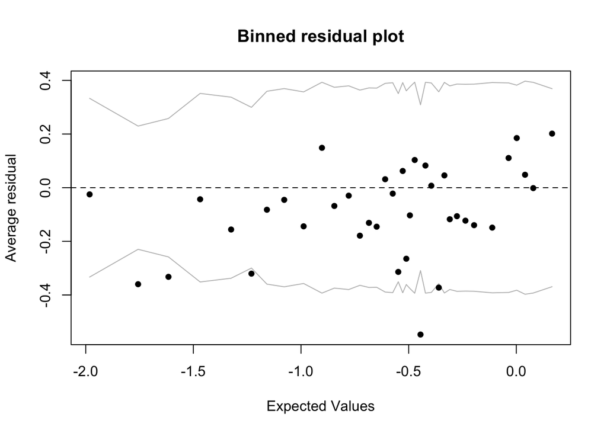

```r
arm::binnedplot(predict(m1), resid(m1))
```

```r
#using the more complex variables works a little better
m2 <- glm(bush_vote ~ female + race + educ1 + income + urban + age, data=bush_data, family=binomial(link="logit"))
summary(m2)
```

```
##
## Call:
## glm(formula = bush_vote ~ female + race + educ1 + income + urban +
##     age, family = binomial(link = "logit"), data = bush_data)
##
## Deviance Residuals:
##     Min       1Q   Median       3Q      Max
## -1.5940  -0.9906  -0.7666   1.2506   2.6070
##
## Coefficients:
##                                                Estimate Std. Error z value
## (Intercept)                                   -2.051953   0.461624  -4.445
## female                                         0.065350   0.121483   0.538
## race2. black                                  -2.276669   0.372213  -6.117
## race3. asian                                   0.900124   0.493534   1.824
## race4. native american                        -0.043262   0.371368  -0.116
## race5. hispanic                               -0.078654   0.302043  -0.260
## educ12. high school (12 grades or fewer, incl  0.326300   0.322020   1.013
## educ13. some college(13 grades or more,but no  0.404551   0.340567   1.188
## educ14. college or advanced degree (no cases   0.707949   0.342324   2.068
## income2. 17 to 33 percentile                   0.355509   0.263765   1.348
## income3. 34 to 67 percentile                   0.391210   0.249708   1.567
## income4. 68 to 95 percentile                   0.543567   0.251581   2.161
## income5. 96 to 100 percentile                  0.691210   0.336771   2.052
## urban2. suburban areas                         0.505196   0.161254   3.133
## urban3. rural, small towns, outlying and adja  0.498115   0.171804   2.899
## age                                            0.006021   0.003862   1.559
##                                               Pr(>|z|)
## (Intercept)                                   8.79e-06 ***
## female                                         0.59062
## race2. black                                  9.56e-10 ***
## race3. asian                                   0.06818 .
## race4. native american                         0.90726
## race5. hispanic                                0.79455
## educ12. high school (12 grades or fewer, incl  0.31092
## educ13. some college(13 grades or more,but no  0.23488
## educ14. college or advanced degree (no cases   0.03863 *
## income2. 17 to 33 percentile                   0.17771
## income3. 34 to 67 percentile                   0.11719
## income4. 68 to 95 percentile                   0.03073 *
## income5. 96 to 100 percentile                  0.04012 *
## urban2. suburban areas                         0.00173 **
## urban3. rural, small towns, outlying and adja  0.00374 **
## age                                            0.11899
## ---
## Signif. codes:  0 '***' 0.001 '**' 0.01 '*' 0.05 '.' 0.1 ' ' 1
##
## (Dispersion parameter for binomial family taken to be 1)
##
##     Null deviance: 1758.8  on 1355  degrees of freedom
## Residual deviance: 1626.6  on 1340  degrees of freedom
##   (50 observations deleted due to missingness)
## AIC: 1658.6
##
## Number of Fisher Scoring iterations: 5
```

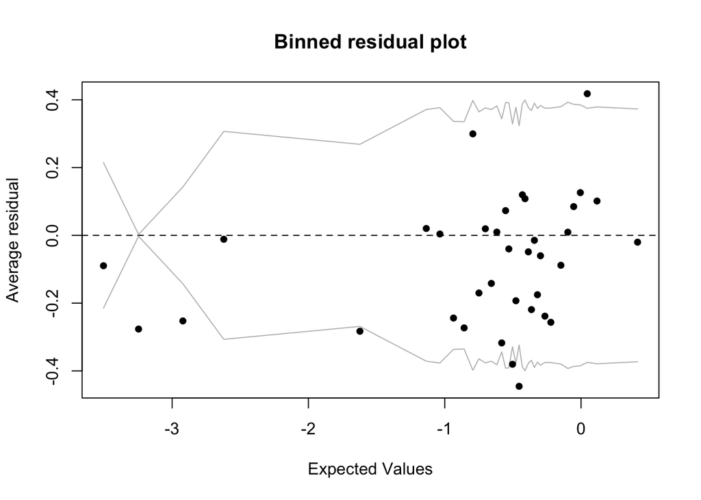

```r
arm::binnedplot(predict(m2), resid(m2))
```

```r
#refined model - ideology is a major predictor and probably confounds the other variables
m3 <- glm(bush_vote ~ white + income_var + ideo, data=bush_data, family=binomial(link="logit"))
summary(m3)
```

```
##
## Call:
## glm(formula = bush_vote ~ white + income_var + ideo, family = binomial(link = "logit"),
##     data = bush_data)
##
## Deviance Residuals:
##     Min       1Q   Median       3Q      Max
## -1.4074  -0.8709  -0.4759   0.9637   2.4927
##
## Coefficients:
##                                        Estimate Std. Error z value
## (Intercept)                             -3.4150     0.2995 -11.404
## white                                    0.9400     0.1789   5.255
## income_varMiddle third                   0.3540     0.2466   1.435
## income_varUpper third                    0.5828     0.2482   2.348
## ideo3. moderate ('middle of the road')   1.3469     0.2640   5.101
## ideo5. conservative                      2.4183     0.1682  14.381
##                                        Pr(>|z|)
## (Intercept)                             < 2e-16 ***
## white                                  1.48e-07 ***
## income_varMiddle third                   0.1512
## income_varUpper third                    0.0189 *
## ideo3. moderate ('middle of the road') 3.38e-07 ***
## ideo5. conservative                     < 2e-16 ***
## ---
## Signif. codes:  0 '***' 0.001 '**' 0.01 '*' 0.05 '.' 0.1 ' ' 1
##
## (Dispersion parameter for binomial family taken to be 1)
##
##     Null deviance: 1766.3  on 1350  degrees of freedom
## Residual deviance: 1427.3  on 1345  degrees of freedom
##   (55 observations deleted due to missingness)
## AIC: 1439.3
##
## Number of Fisher Scoring iterations: 5
```

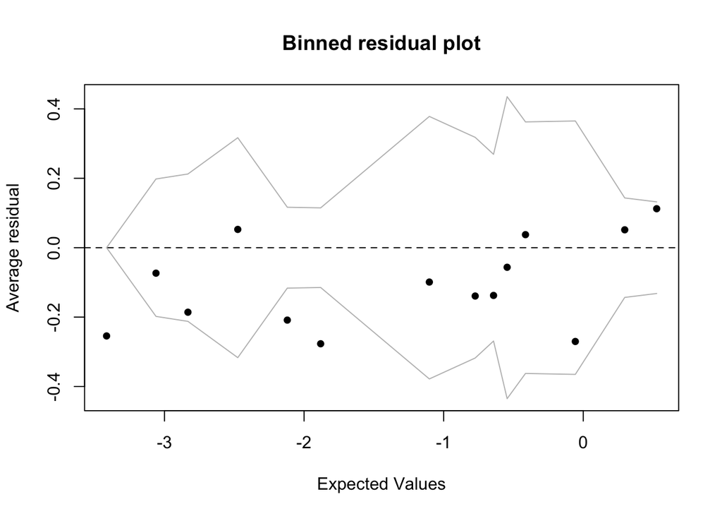

```r
arm::binnedplot(predict(m3), resid(m3))
```

## Question 2

Sketch without a computer (so not labeled), $Pr(y = 1) =$  
a.) $logit^{-1}(x)$  
b.) $logit^{-1}(x + 2)$  
c.) $logit^{-1}(2x)$  
d.) $logit^{-1}(2 + 2x)$  
e.) $logit^{-1}(-2x)$

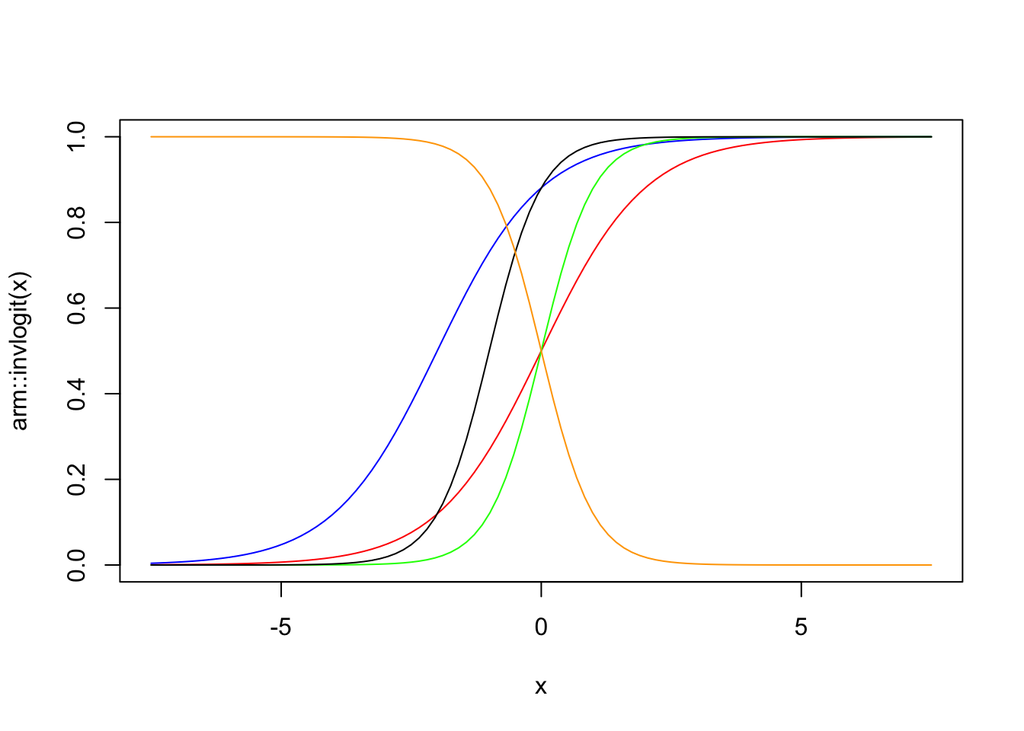

## Question 3

Research question: parents’ income as a predictor of HS graduation for child.  
- Parents with no income: 27% graduation probability.  
- Parents earning $60,000: 88% graduation probability.

Find a logistic model consistent with this. (x can be in $10K units).
$$logit(y) = \beta_0 + \beta_1 x$$

$$Pr(y = 1|x = 0) = 0.27 \rightarrow \beta_0 = logit(0.27) = -0.99$$
$$Pr(y = 1|x = 6) = 0.88 \rightarrow \beta_1 = \frac{logit(0.88) + 0.99}{6} = 0.5$$

$$logit(y) = -0.99 + 0.5x$$

```r
arm::invlogit(-0.99)
```

```
## [1] 0.2709121
```

```r
arm::invlogit(-0.99 + 0.5 * 6)
```

```
## [1] 0.881843
```

## Question 4 Pick and do your own problem (pass)

## Question 5

In a class of 50 students, a logistic regression of course grade (pass/fail) predicted by midterm grade (continuous, $\mu = 60, \sigma = 15$).
$$logit(Pr(pass)) = -24 + 0.4x$$

### a) Plot fitted model and some example data

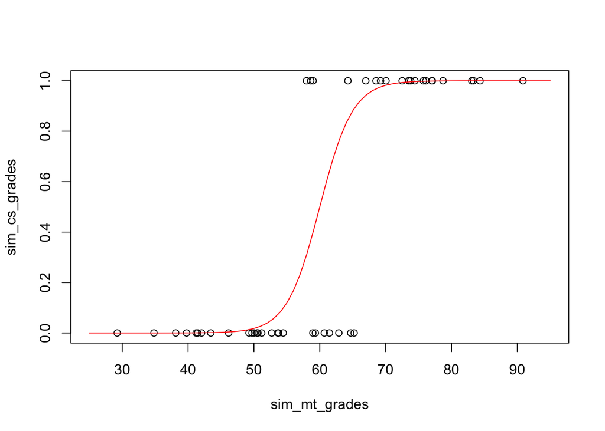

```r
sim_mt_grades = rnorm(50, 60, 15)
sim_cs_grades = rbinom(50, 1, prob = arm::invlogit(-24 + 0.4 *sim_mt_grades))

plot(sim_mt_grades, sim_cs_grades, xlim = c(25, 95), ylim = c(0,1))

#model fit
midterm_grade_input = 25:95
lines(midterm_grade_input, arm::invlogit(-24 + 0.4 *midterm_grade_input),  xlim = c(25, 95), ylim = c(0,1), col = "red")
```

### c) Create a random noise variable (N(0,1)), how does it affect the deviance?

This question seems out of place, but using the example data. The deviance will likely decrease but not substantially.

```r
grade_model = glm(sim_cs_grades ~ sim_mt_grades)
deviance(grade_model)
```

```
## [1] 5.07717
```

```r
newpred = rnorm(50)
grade_model2 = glm(sim_cs_grades ~ sim_mt_grades + newpred)
deviance(grade_model2)
```

```
## [1] 4.930609
```

## Question 6